# Air quality indicators and lung disease across the United States

Final Project: Executive Summary  
Data Science 1 with R (STAT 301-1)

Author

Cassie Lee

Published

November 29, 2023

**Github Repo Link**

[Cassie’s Final Project Github Repo Link](https://github.com/stat301-1-2023-fall/final-project-1-cassielee2025.git)

# Introduction

Air pollution is the presence of sufficient quantities of contaminants in the atmosphere for a duration that is long enough to cause harm to human health (World Health Organization, n.d.). This report explores the relationships between air quality indicators, certain lung diseases, and how sociodemographic vulnerabilities affect the relationships between air quality and health in the United States (excluding territories) to build a deeper understanding of how various air pollutants impact health across the United States.

2018 county level data was downloaded from the CDC National Environmental Public Health Tracking Network interactive data explorer (Centers for Disease Control and Prevention, n.d.).

The three central questions explored in this analysis were:

1. How are various air quality indicators related to each other?
2. What are the most important indicators for determining the prevalence of asthma, cancer, and chronic obstructive pulmonary disease?
3. How do sociodemographics like age, gender, race, and the social vulnerability index affect the relationships between lung disease and air quality?

# Indicators of air and environmental quality

The two main categories of air quality indicators selected were days over the ozone and PM 2.5 pollution and the concentrations of the pollutants benzene, formaldehyde, acetaldehyde, carbon tetrachloride, and 1,3-butadiene. Major conclusions from analysis between air quality indicators are:

1. There is significant missing data about the days over the ozone and PM 2.5 standards, however, Figure 1 shows that counties along the west coast, especially California tended to have this data reported. The days over the PM 2.5 standard aligns with the 2018 wildfire incident map (Cal Fire, n.d.).
2. The distributions of benzene, formaldehyde, acetaldehyde, and 1,3-butadiene pollution across counties were right skewed, but the distribution of carbon tetrachloride was left skewed. This may be due to carbon tetrachloride not having any natural sources, so there are several counties that can have extremely low levels of this pollutant (Agency for Toxic Substances and Disease Registry, 2019; Agency for Toxic Substances and Disease Registry, 2023; Agency for Toxic Substances and Disease Registry, n.d.-a.; Agency for Toxic Substances and Disease Registry, n.d.-b; National Institute of Environmental Health Sciences, n.d.).
3. Figure 2 shows that the days over the ozone and PM 2.5 standards were positively correlated, likely because these pollutants share some sources of pollution (ex: nitrogen oxides from power plants, industrial pollution, and automobiles). However, ozone and PM 2.5 pollution were not particularly correlated with the other 5 pollutants. This is likely because the five chemicals are nearly strictly from industrial pollution, while ozone and PM 2.5 pollution can have significant non-industrial sources, such as from automobiles.

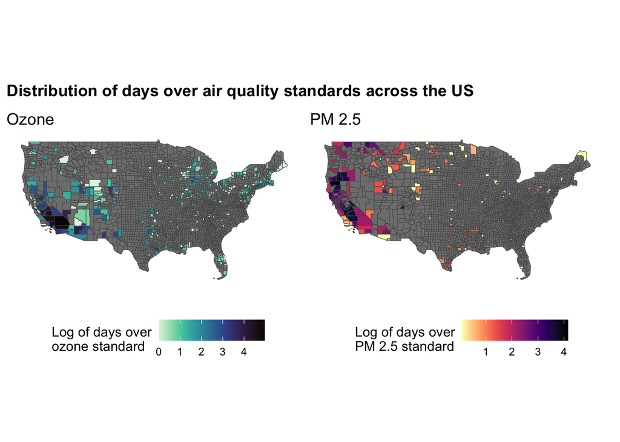

Figure 1: Distribution of days over the ozone and PM 2.5 standard across the United States, excluding Hawaii and Alaska.

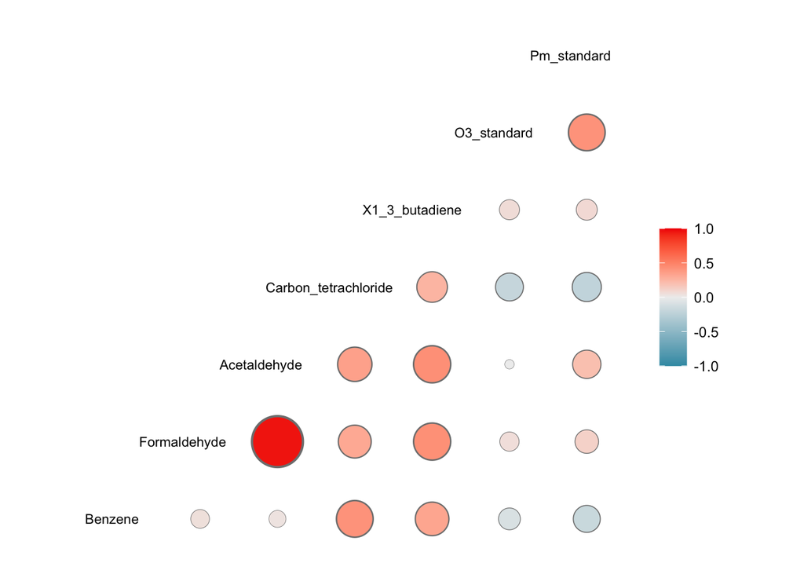

Figure 2: Correlation matrix of all air quality indicators.

# Asthma

The first lung disease explored in this analysis was asthma. Major conclusions from analysis between asthma and air quality are:

1. The prevalence of both child and adult asthma was most strongly correlated with formaldehyde and acetaldehyde pollution.
2. Figure 3 shows that for counties with a high proportion of young or old individuals, it is clear that emergency department visits for asthma increased when the days over the ozone and PM 2.5 pollution increased.
3. Figure 4 shows that in general, the effect of poor air quality on emergency department visits for asthma was larger for counties with a relatively higher proportion of women. The exception to this is PM 2.5, and this could be due to gendered differences in risk perception for poor air quality (Brown et al., 2021).
4. Predominantly Black counties had higher a higher prevalence of adult asthma and higher levels of formaldehyde and acetaldehyde pollution than predominantly white counties. However, the effect of increased pollution concentrations on the prevalence of adult asthma was not significantly different between predominantly Black and predominantly white counties.

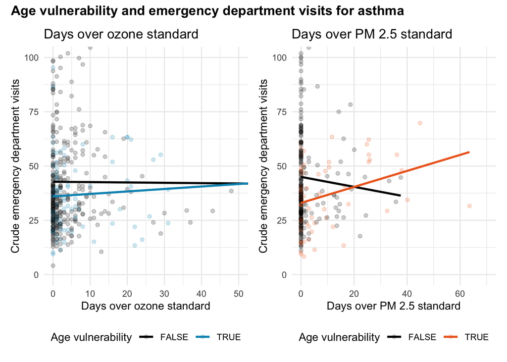

Figure 3: The crude rate of emergency deartment visits for asthma per 10 K population as a function of days over the ozone and PM 2.5 standard, disaggregated by demographic age vulnerability.

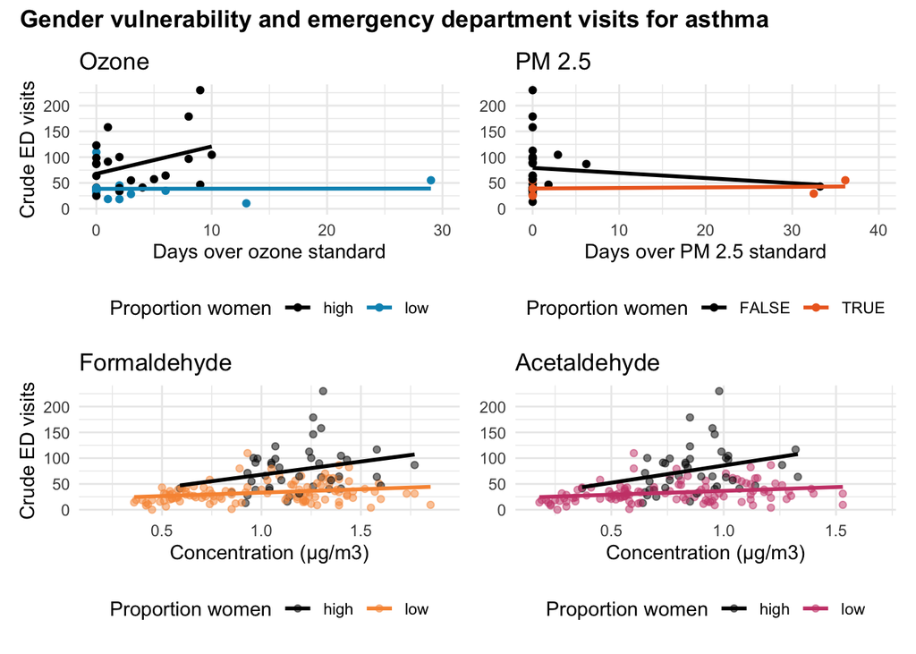

Figure 4: The crude rate of emergency deartment visits for asthma per 10 K population as a function of days over the ozone and PM 2.5 standard and the pollutnats formaldehyde and acetaldehyde, disaggregated by gender vulnerability.

# Lung and bronchus cancer

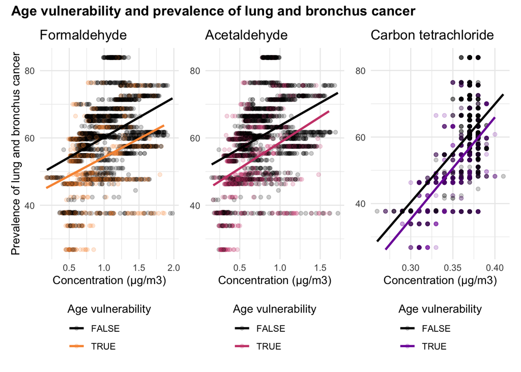

Figure 5: The prevalence of lung and bronchus cancer per 100 K population as a function of the pollutants formaldehyde, acetaldehyde, and carbon tetrachloride, disaggregated by demographic age vulnerability.

[figure not shown]

Figure 6: The prevalence of lung and bronchus cancer per 100 K population as a function of the pollutnats formaldehyde, acetaldehyde, and carbon tetrachloride, disaggregated by predominant race.

# Chronic obstructive pulmonary disease

The final lung disease explored in this analysis was chronic obstructive pulmonary disease (COPD). Major conclusions from analysis between COPD and air quality are:

1. Figure 7 shows that like lung and bronchus cancer, formaldehyde, acetaldehyde, and carbon tetrachloride pollution were strongly correlated with COPD. This is consistent with studies showing that formaldehyde exposure through inhalation increases the risk of COPD (Bentayeb et al., 2015; Malaka & Kodama, 1990).
2. Similar to lung and bronchus cancer, counties with a higher proportion of younger and older individuals generally had a lower prevalence of COPD, and increased formaldehyde and acetaldehyde concentrations had a larger effect on COPD for counties with a relatively high proportion of men
3. Between predominantly Black and white counties, the predominant race did not particularly affect the relationship between COPD and the pollutants formaldehyde and acetaldehyde.

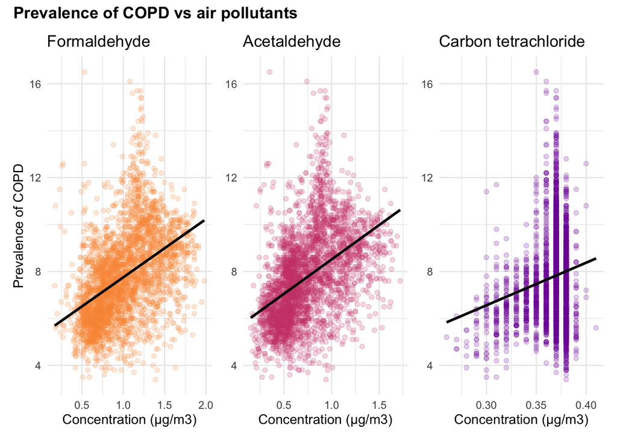

Figure 7: Age adjusted percentage of COPD as a function of the pollutants formaldehyde, acetaldehyde, and carbon tetrachloride.

# Conclusions

The air quality indicators of the days over the ozone and PM 2.5 standards were more predictive of acute effects on health, while the air quality indicators of pollution concentrations were more predictive of chronic effects on health.

Acute air pollution as measured by the days over the ozone and PM 2.5 standards had significant effects on the rate of emergency department visits for counties with a high proportion of young or old individuals. Counties with demographic age vulnerabilities should take extra measures to enable residents to reduce acute exposure to poor air quality.

Chronic air pollution as measured by the concentrations of formaldehyde, acetaldehyde, and carbon tetrachloride had significant effects on the prevalence of child and adult asthma, lung and bronchus cancer, and COPD. Industrial pollution needs to be systematically reduced in predominantly Black counties, and counties with a relatively high proportion of men should work to reduce exposure to these industrial air pollutants, possibly through review of occupational safety standards.

# Sources

Agency for Toxic Substances and Disease Registry. (n.d.-a). Public Health Statement for 1,3-Butadiene. Retrieved November 28, 2023, from https://wwwn.cdc.gov/TSP/PHS/PHS.aspx?phsid=457&toxid=81#bookmark02

Agency for Toxic Substances and Disease Registry. (n.d.-b). Public Health Statement for Formaldehyde. Retrieved November 28, 2023, from https://wwwn.cdc.gov/TSP/PHS/PHS.aspx?phsid=218&toxid=39

Agency for Toxic Substances and Disease Registry. (2019, January 3). Benzene. https://www.atsdr.cdc.gov/sites/toxzine/benzene_toxzine.html

Agency for Toxic Substances and Disease Registry. (2023, May 25). Carbon Tetrachloride Toxicity: Where Is Carbon Tetrachloride Found? https://www.atsdr.cdc.gov/csem/carbon-tetrachloride/where_found.html

Bentayeb, M., Norback, D., Bednarek, M., Bernard, A., Cai, G., Cerrai, S., Eleftheriou, K. K., Gratziou, C., Holst, G. J., Lavaud, F., Nasilowski, J., Sestini, P., Sarno, G., Sigsgaard, T., Wieslander, G., Zielinski, J., Viegi, G., & Annesi-Maesano, I. (2015). Indoor air quality, ventilation and respiratory health in elderly residents living in nursing homes in Europe. European Respiratory Journal, 45(5), 1228–1238. https://doi.org/10.1183/09031936.00082414

Brown, G. D., Largey, A., & McMullan, C. (2021). The impact of gender on risk perception: Implications for EU member states’ national risk assessment processes. International Journal of Disaster Risk Reduction, 63, 102452. https://doi.org/10.1016/j.ijdrr.2021.102452

Cal Fire. (n.d.). 2018 Fire Season Incident Archive. Retrieved November 28, 2023, from https://www.fire.ca.gov/incidents/2018

Centers for Disease Control and Prevention. (n.d.). National Environmental Public Health Tracking Network. Retrieved November 28, 2023, from https://ephtracking.cdc.gov

Malaka, T., & Kodama, A. M. (1990). Respiratory Health of Plywood Workers Occupationally Exposed to Formaldehyde. Archives of Environmental Health: An International Journal, 45(5), 288–294. https://doi.org/10.1080/00039896.1990.10118748

McGwin, G., Lienert, J., & Kennedy, J. I. (2010). Formaldehyde Exposure and Asthma in Children: A Systematic Review. Environmental Health Perspectives, 118(3), 313–317. https://doi.org/10.1289/ehp.0901143

National Institute of Environmental Health Sciences. (n.d.). Acetaldehyde (Report on Carcinogens, Fifteenth Edition). Retrieved November 28, 2023, from https://ntp.niehs.nih.gov/sites/default/files/ntp/roc/content/profiles/acetaldehyde.pdf

OECD. (2020). Gender and environmental statistics: Exploring available data and developing new evidence. https://www.oecd.org/environment/brochure-gender-and-environmental-statistics.pdf

US EPA, O. (n.d.). Carbon tetrachloride. Retrieved November 28, 2023, from https://www.epa.gov/sites/default/files/2016-09/documents/carbon-tetrachloride.pdf

World Health Organization. (n.d.). Air quality and health. Retrieved November 28, 2023, from https://www.who.int/teams/environment-climate-change-and-health/air-quality-and-health/health-impacts